# M01-2-Introduction to Literate Programming-Application Assignment

Author

Alexa Bueno

Published

July 26, 2026

# 1 M01-2 Application Assignment

## 1.1 Ex 1

> Create a variable called X and assign the text “This is my first assignment” to it.

```r
X <- "This is my first assignment"
X
```

```
[1] "This is my first assignment"
```

## 1.2 Ex 2: Adding Texts in Base R

### 1.2.1 Ex 2.1 Learning `paste()`

**Tip**

I used a few examples to see how `paste()` and `paste0()` work differently.

```r
paste("Hello", "world")
```

```
[1] "Hello world"
```

```r
paste("Hello", "world", sep = "-")
```

```
[1] "Hello-world"
```

```r
paste0("Hello", "world")
```

```
[1] "Helloworld"
```

### 1.2.2 Ex 2.2 Adding text to `X`

```r
X <- paste(X, "and I'm loving it!")
X
```

```
[1] "This is my first assignment and I'm loving it!"
```

## 1.3 Ex 3

> Create a vector called Y with the numbers 2, 3, 4, and 5. Then multiply the vector by 2.

```r
Y <- c(2, 3, 4, 5)
Y <- Y * 2
Y
```

```
[1]  4  6  8 10
```

## 1.4 Ex 4

> Print both the variable `X` and the vector `Y`.

```r
X
```

```
[1] "This is my first assignment and I'm loving it!"
```

```r
Y
```

```
[1]  4  6  8 10
```

## 1.5 Ex 5

> Show the maximum and minimum value of `Y`.

```r
max(Y)
```

```
[1] 10
```

```r
min(Y)
```

```
[1] 4
```

## 1.6 Ex 6

> Load the `ggplot2` package and look at the first six rows of `economics`.

```r
# install.packages("ggplot2")
library(ggplot2)

head(economics)
```

```
# A tibble: 6 × 6
  date         pce    pop psavert uempmed unemploy
  <date>     <dbl>  <dbl>   <dbl>   <dbl>    <dbl>
1 1967-07-01  507. 198712    12.6     4.5     2944
2 1967-08-01  510. 198911    12.6     4.7     2945
3 1967-09-01  516. 199113    11.9     4.6     2958
4 1967-10-01  512. 199311    12.9     4.9     3143
5 1967-11-01  517. 199498    12.8     4.7     3066
6 1967-12-01  525. 199657    11.8     4.8     3018
```

## 1.7 Ex 7

### 1.7.1 Understanding the `economics` Data

The `economics` data has six variables:

- `date`: the month and year of the observation
- `pce`: personal consumption expenditures
- `pop`: total population
- `psavert`: personal savings rate
- `uempmed`: median duration of unemployment
- `unemploy`: number of unemployed people

I decided to compare `unemploy` and `uempmed` because I wanted to see if more unemployment is connected to people staying unemployed longer.

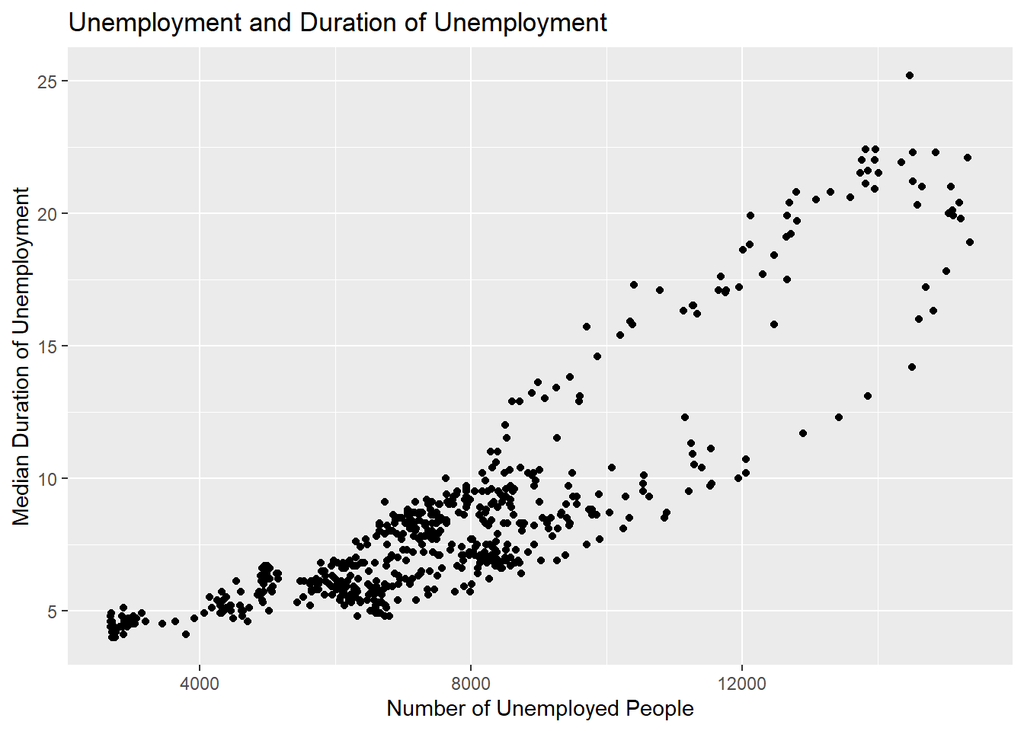

```r
plot <- ggplot(economics, aes(x = unemploy, y = uempmed)) +
  geom_point()

plot +
  labs(
    title = "Unemployment and Duration of Unemployment",
    x = "Number of Unemployed People",
    y = "Median Duration of Unemployment"
  )
```

## 1.8 Ex 8

> I recreated the chart using the pipe operator.

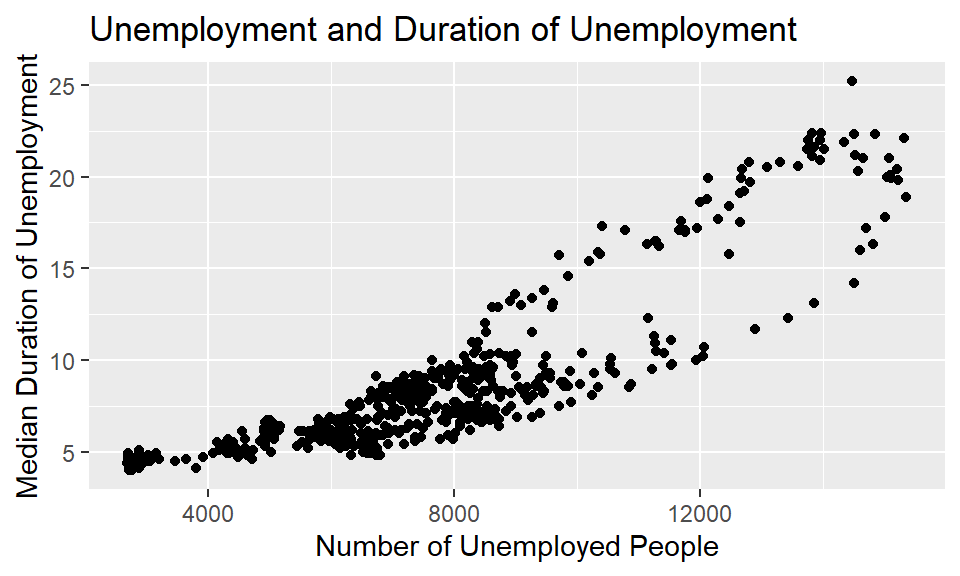

Figure 1: Scatterplot showing unemployment and median duration of unemployment.

```r
economics |>
  ggplot(aes(x = unemploy, y = uempmed)) +
  geom_point() +
  labs(
    title = "Unemployment and Duration of Unemployment",
    x = "Number of Unemployed People",
    y = "Median Duration of Unemployment"
  )
```

## 1.9 Ex 9

**Note**

In Figure 1, it looks like there is a positive relationship between unemployment and median unemployment duration. When the number of unemployed people is higher, the median amount of time people stay unemployed also seems to be higher.

## 1.10 Ex 10

**Important**

I tried to organize this codebook so it would be easier to read later.

### 1.10.1 What I used in this report

1. I used headings with `#`, `##`, and `###`.
2. I used **bold text** for emphasis.
3. I used *italicized text* in the report.
4. I used `callout-tip` for a hint/note.
5. I used `callout-note` to explain my finding.
6. I used `callout-important` for an important organization note.
7. I used blockquotes for some task instructions.
8. I used backticks around R functions like `paste()` and `ggplot()`.
9. I cross-referenced the figure with Figure 1.
10. I used `#|` options inside a code chunk.
11. I added a table of contents in the YAML header.
12. I used numbered sections in the YAML header.
13. I added a figure caption.
14. I used separate code chunks for each question.
15. I used bullet points to explain the variables.

Overall, this assignment helped me practice putting code, notes, and output together in one Quarto document.